# CNN - Modelling (Multi + TH + Standalone TL)

# 1. Construct MLP

```python
import tensorflow as tf
%matplotlib inline

CLASS = "Mul"
PRE = "TH"
TECH = "Standalone_TF"

print(tf.__version__)
```

```
2.4.2
```

```python
! nvidia-smi
```

```
/bin/bash: switchml: line 1: syntax error: unexpected end of file
/bin/bash: error importing function definition for `switchml'
/bin/bash: _moduleraw: line 1: syntax error: unexpected end of file
/bin/bash: error importing function definition for `_moduleraw'
Mon Aug 23 01:28:09 2021
+-----------------------------------------------------------------------------+
| NVIDIA-SMI 450.142.00   Driver Version: 450.142.00   CUDA Version: 11.0     |
|-------------------------------+----------------------+----------------------+
| GPU  Name        Persistence-M| Bus-Id        Disp.A | Volatile Uncorr. ECC |
| Fan  Temp  Perf  Pwr:Usage/Cap|         Memory-Usage | GPU-Util  Compute M. |
|                               |                      |               MIG M. |
|===============================+======================+======================|
|   0  Tesla T4            On   | 00000000:00:1E.0 Off |                    0 |
| N/A   32C    P8     9W /  70W |      0MiB / 15109MiB |      0%      Default |
|                               |                      |                  N/A |
+-------------------------------+----------------------+----------------------+

+-----------------------------------------------------------------------------+
| Processes:                                                                  |
|  GPU   GI   CI        PID   Type   Process name                  GPU Memory |
|        ID   ID                                                   Usage      |
|=============================================================================|
|  No running processes found                                                 |
+-----------------------------------------------------------------------------+
```

Use MLP on the extracted features to make prediction.

```python
from crack_utils import classification_block
from tensorflow.keras.models import Model
from tensorflow.keras.layers import Input

# define MLP model
def MLP(input_size):
    # define model input
    visible = Input(shape=(input_size, ))
    # add classification block
    layer = classification_block(visible, 32, classes=5)
    # create model
    model = Model(inputs=visible, outputs=layer)
    return model
```

# 2. Pretrain Model as Standalone Feature Extractor

Use all layes previous to the output layer.

## 2.1 VGG19

```python
from tensorflow.keras.applications import VGG19

# create model instance
model = VGG19()
# remove the output layer
model = Model(inputs=model.inputs, outputs=model.layers[-2].output)
```

[output not shown]

Preprocess images and extract features: Due to the insufficient memory issue, we extract the features in 10 batches:

```python
from crack_utils import load_multi_dataset, extract_in_batch, augment_data
from tensorflow.keras.applications.vgg19 import preprocess_input as pre_vgg19
from tensorflow.keras.preprocessing.image import ImageDataGenerator
from tensorflow.keras.utils import to_categorical

SRC_MULTI = "/home/ubuntu/crack/TH-Multi"

x_train, x_test, y_train, y_test = load_multi_dataset(SRC_MULTI, (224, 224))

x_train = extract_in_batch(10, x_train, model, "train", pre_vgg19)
x_test = extract_in_batch(10, x_test, model, "test", pre_vgg19)

# convert integers to dummy variables (i.e. one hot encoded)
y_train = to_categorical(y_train)
y_test = to_categorical(y_test)

feature_length = x_train.shape[1]
```

```
Processing 10 batch of test-set....
```

Fit MLP model:

```python
%%time

from crack_utils import multiple_compile

# create model instance
model = MLP(feature_length)
multiple_compile(model, 0.01, 0.9)

# fit the model
histories = dict()

model_name = "{}_{}_TL1_VGG19".format(CLASS, PRE)
histories[model_name] = model.fit(x=x_train, y=y_train, batch_size=64,
              validation_data=(x_test, y_test), epochs=30, verbose=0).history
```

```
CPU times: user 6.03 s, sys: 688 ms, total: 6.72 s
Wall time: 4.58 s
```

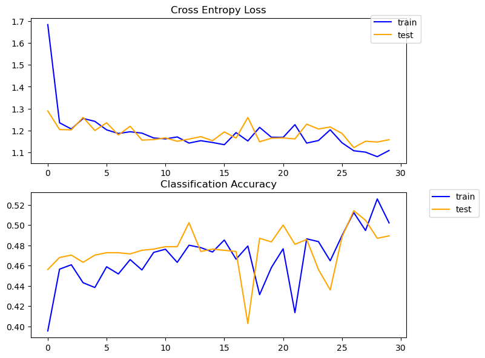

```python
from crack_utils import summarize_diagnostics_multi

summarize_diagnostics_multi(histories[model_name], "model_plot/{}.png".format(model_name))
```

```python
from crack_utils import show_result_multi

results = dict()

results[model_name] = show_result_multi(model, x_test, y_test, y_test)
```

```
Test loss: 1.16
Test accuracy: 0.49
Test f1 micro: 0.49
Test f1 macro: 0.32
Test f1 weighted: 0.39
```

## 2.2 ResNet152V2

```python
from tensorflow.keras.applications import ResNet152V2

# create model instance
model = ResNet152V2()
# remove the output layer
model = Model(inputs=model.inputs, outputs=model.layers[-2].output)
```

Preprocess images and extract features: Due to the insufficient memory issue, we extract the features in 10 batches:

```python
from tensorflow.keras.applications.resnet_v2 import preprocess_input as pre_resnet_v2

del x_train, x_test
x_train, x_test, y_train, y_test = load_multi_dataset(SRC_MULTI, (224, 224))

x_train = extract_in_batch(10, x_train, model, "train", pre_resnet_v2)
x_test = extract_in_batch(10, x_test, model, "test", pre_resnet_v2)

# convert integers to dummy variables (i.e. one hot encoded)
y_train = to_categorical(y_train)
y_test = to_categorical(y_test)

feature_length = x_train.shape[1]
```

```
Processing 10 batch of test-set....
```

Fit MLP model:

```python
%%time

# create model instance
model = MLP(feature_length)
multiple_compile(model, 0.01, 0.9)

# fit the model
model_name = "{}_{}_TL1_ResNet152V2".format(CLASS, PRE)
histories[model_name] = model.fit(x=x_train, y=y_train, batch_size=64,
              validation_data=(x_test, y_test), epochs=30, verbose=0).history
```

```
CPU times: user 5.32 s, sys: 607 ms, total: 5.93 s
Wall time: 3.87 s
```

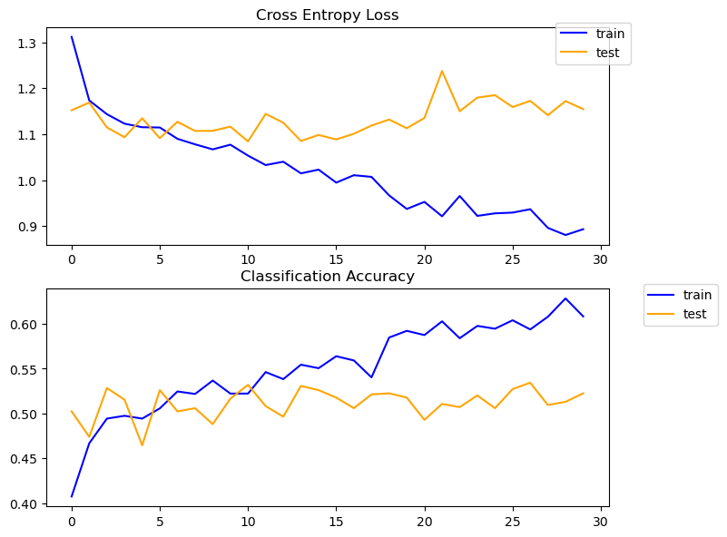

```python
summarize_diagnostics_multi(histories[model_name], "model_plot/{}.png".format(model_name))
```

```python
results[model_name] = show_result_multi(model, x_test, y_test, y_test)
```

```
Test loss: 1.15
Test accuracy: 0.52
Test f1 micro: 0.52
Test f1 macro: 0.48
Test f1 weighted: 0.52
```

## 2.3 NASNetLarge

```python
from tensorflow.keras.applications import NASNetLarge

# create model instance
model = NASNetLarge()
# remove the output layer
model = Model(inputs=model.inputs, outputs=model.layers[-2].output)
```

```python
from tensorflow.keras.applications.nasnet import preprocess_input as pre_nasnet

del x_train, x_test
x_train, x_test, y_train, y_test = load_multi_dataset(SRC_MULTI, (331, 331))

x_train = extract_in_batch(10, x_train, model, "train", pre_nasnet)
x_test = extract_in_batch(10, x_test, model, "test", pre_nasnet)

# convert integers to dummy variables (i.e. one hot encoded)
y_train = to_categorical(y_train)
y_test = to_categorical(y_test)

feature_length = x_train.shape[1]
```

```
Processing 10 batch of test-set....
```

Fit MLP model:

```python
%%time

# create model instance
model = MLP(feature_length)
multiple_compile(model, 0.01, 0.9)

# fit the model
model_name = "{}_{}_TL1_NASNetLarge".format(CLASS, PRE)
histories[model_name] = model.fit(x=x_train, y=y_train, batch_size=64,
              validation_data=(x_test, y_test), epochs=30, verbose=0).history
```

```
CPU times: user 5.74 s, sys: 705 ms, total: 6.44 s
Wall time: 4.21 s
```

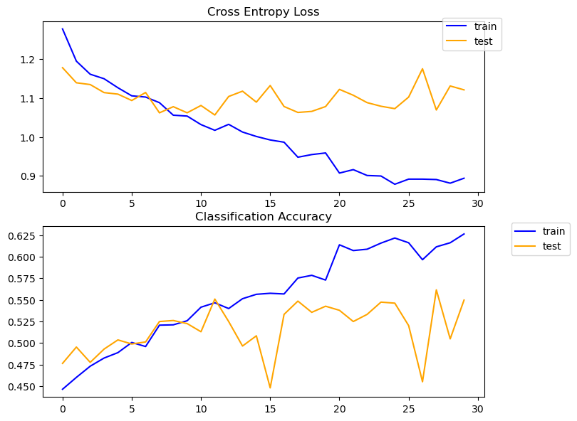

```python
summarize_diagnostics_multi(histories[model_name], "model_plot/{}.png".format(model_name))
```

```python
results[model_name] = show_result_multi(model, x_test, y_test, y_test)
```

```
Test loss: 1.12
Test accuracy: 0.55
Test f1 micro: 0.55
Test f1 macro: 0.50
Test f1 weighted: 0.52
```

## 2.4 DenseNet201

```python
from tensorflow.keras.applications import DenseNet201

# create model instance
model = DenseNet201()
# remove the output layer
model = Model(inputs=model.inputs, outputs=model.layers[-2].output)
```

Preprocess images and extract features: Due to the insufficient memory issue, we extract the features in 10 batches:

```python
from tensorflow.keras.applications.densenet import preprocess_input as pre_densenet

del x_train, x_test
x_train, x_test, y_train, y_test = load_multi_dataset(SRC_MULTI, (224, 224))

x_train = extract_in_batch(10, x_train, model, "train", pre_densenet)
x_test = extract_in_batch(10, x_test, model, "test", pre_densenet)

# convert integers to dummy variables (i.e. one hot encoded)
y_train = to_categorical(y_train)
y_test = to_categorical(y_test)

feature_length = x_train.shape[1]
```

```
Processing 10 batch of test-set....
```

Fit MLP model:

```python
%%time

from crack_utils import binary_compile

# create model instance
model = MLP(feature_length)
multiple_compile(model, 0.01, 0.9)

# fit the model
model_name = "{}_{}_TL1_DenseNet201".format(CLASS, PRE)
histories[model_name] = model.fit(x=x_train, y=y_train, batch_size=64,
              validation_data=(x_test, y_test), epochs=30, verbose=0).history
```

```
CPU times: user 5.31 s, sys: 645 ms, total: 5.96 s
Wall time: 3.84 s
```

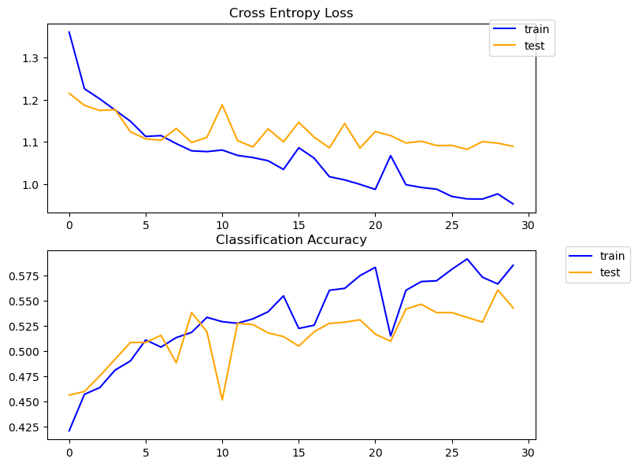

```python
summarize_diagnostics_multi(histories[model_name], "model_plot/{}.png".format(model_name))
```

```python
results[model_name] = show_result_multi(model, x_test, y_test, y_test)
```

```
Test loss: 1.09
Test accuracy: 0.54
Test f1 micro: 0.54
Test f1 macro: 0.42
Test f1 weighted: 0.50
```

## 2.5 InceptionV3

```python
from tensorflow.keras.applications import InceptionV3

# create model instance
model = InceptionV3()
# remove the output layer
model = Model(inputs=model.inputs, outputs=model.layers[-2].output)
```

Preprocess images and extract features: Due to the insufficient memory issue, we extract the features in 10 batches:

```python
from tensorflow.keras.applications.inception_v3 import preprocess_input as pre_inception_v3

del x_train, x_test
x_train, x_test, y_train, y_test = load_multi_dataset(SRC_MULTI, (299, 299))

x_train = extract_in_batch(10, x_train, model, "train", pre_inception_v3)
x_test = extract_in_batch(10, x_test, model, "test", pre_inception_v3)

# convert integers to dummy variables (i.e. one hot encoded)
y_train = to_categorical(y_train)
y_test = to_categorical(y_test)

feature_length = x_train.shape[1]
```

```
Processing 10 batch of test-set....
```

Fit MLP model:

```python
%%time

# create model instance
model = MLP(feature_length)
multiple_compile(model, 0.01, 0.9)

# fit the model
model_name = "{}_{}_TL1_InceptionV3".format(CLASS, PRE)
histories[model_name] = model.fit(x=x_train, y=y_train, batch_size=64,
              validation_data=(x_test, y_test), epochs=30, verbose=0).history
```

```
CPU times: user 5.32 s, sys: 628 ms, total: 5.95 s
Wall time: 3.82 s
```

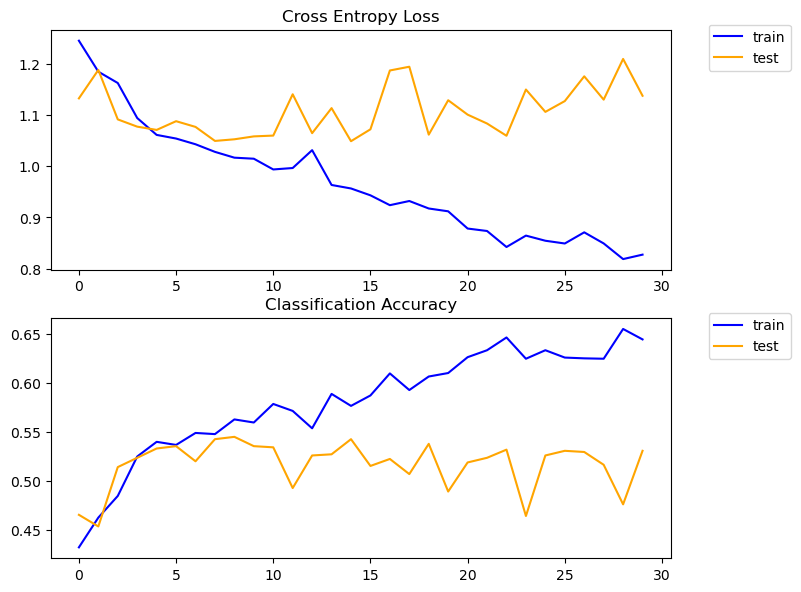

```python
summarize_diagnostics_multi(histories[model_name], "model_plot/{}.png".format(model_name))
```

```python
results[model_name] = show_result_multi(model, x_test, y_test, y_test)
```

```
Test loss: 1.14
Test accuracy: 0.53
Test f1 micro: 0.53
Test f1 macro: 0.47
Test f1 weighted: 0.51
```

## 2.6 InceptionResNetV2

```python
from tensorflow.keras.applications import InceptionResNetV2

# create model instance
model = InceptionResNetV2()
# remove the output layer
model = Model(inputs=model.inputs, outputs=model.layers[-2].output)
```

Preprocess images and extract features: Due to the insufficient memory issue, we extract the features in 10 batches:

```python
from tensorflow.keras.applications.inception_resnet_v2 import preprocess_input as pre_inception_resnet_v2

del x_train, x_test
x_train, x_test, y_train, y_test = load_multi_dataset(SRC_MULTI, (299, 299))

x_train = extract_in_batch(10, x_train, model, "train", pre_inception_resnet_v2)
x_test = extract_in_batch(10, x_test, model, "test", pre_inception_resnet_v2)

# convert integers to dummy variables (i.e. one hot encoded)
y_train = to_categorical(y_train)
y_test = to_categorical(y_test)

feature_length = x_train.shape[1]
```

```
Processing 10 batch of test-set....
```

Fit MLP model:

```python
%%time

# create model instance
model = MLP(feature_length)
multiple_compile(model, 0.01, 0.9)

# fit the model
model_name = "{}_{}_TL1_InceptionResNetV2".format(CLASS, PRE)
histories[model_name] = model.fit(x=x_train, y=y_train, batch_size=64,
              validation_data=(x_test, y_test), epochs=30, verbose=0).history
```

```
CPU times: user 5.21 s, sys: 652 ms, total: 5.86 s
Wall time: 3.77 s
```

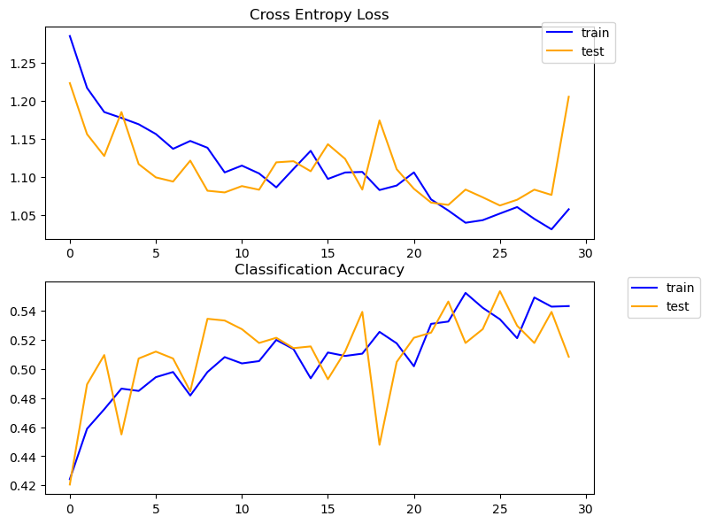

```python
summarize_diagnostics_multi(histories[model_name], "model_plot/{}.png".format(model_name))
```

```python
results[model_name] = show_result_multi(model, x_test, y_test, y_test)
```

```
Test loss: 1.21
Test accuracy: 0.51
Test f1 micro: 0.51
Test f1 macro: 0.31
Test f1 weighted: 0.41
```

## 2.7 Xception

```python
from tensorflow.keras.applications import Xception

# create model instance
model = Xception()
# remove the output layer
model = Model(inputs=model.inputs, outputs=model.layers[-2].output)
```

Preprocess images and extract features: Due to the insufficient memory issue, we extract the features in 10 batches:

```python
from tensorflow.keras.applications.xception import preprocess_input as pre_xception

del x_train, x_test
x_train, x_test, y_train, y_test = load_multi_dataset(SRC_MULTI, (299, 299))

x_train = extract_in_batch(10, x_train, model, "train", pre_xception)
x_test = extract_in_batch(10, x_test, model, "test", pre_xception)

# convert integers to dummy variables (i.e. one hot encoded)
y_train = to_categorical(y_train)
y_test = to_categorical(y_test)

feature_length = x_train.shape[1]
```

```
Processing 10 batch of test-set....
```

Fit MLP model:

```python
%%time

# create model instance
model = MLP(feature_length)
multiple_compile(model, 0.01, 0.9)

# fit the model
model_name = "{}_{}_TL1_InceptionXception".format(CLASS, PRE)
histories[model_name] = model.fit(x=x_train, y=y_train, batch_size=64,
              validation_data=(x_test, y_test), epochs=30, verbose=0).history
```

```
CPU times: user 5.29 s, sys: 677 ms, total: 5.97 s
Wall time: 3.82 s
```

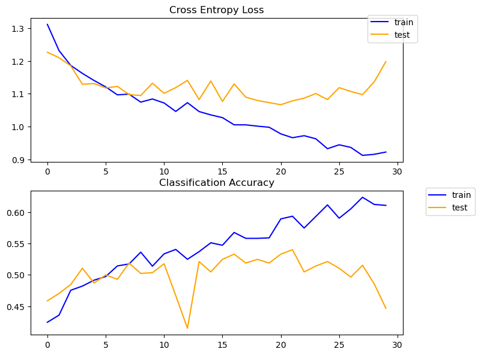

```python
summarize_diagnostics_multi(histories[model_name], "model_plot/{}.png".format(model_name))
```

```python
results[model_name] = show_result_multi(model, x_test, y_test, y_test)
```

```
Test loss: 1.20
Test accuracy: 0.45
Test f1 micro: 0.45
Test f1 macro: 0.43
Test f1 weighted: 0.44
```

# 3. Summary

Final result:

```python
from crack_utils import get_final_result

get_final_result(results).round(2)
```

|  | Mul_TH_TL1_VGG19 | Mul_TH_TL1_ResNet152V2 | Mul_TH_TL1_NASNetLarge | Mul_TH_TL1_DenseNet201 | Mul_TH_TL1_InceptionV3 | Mul_TH_TL1_InceptionResNetV2 | Mul_TH_TL1_InceptionXception |
| --- | --- | --- | --- | --- | --- | --- | --- |
| Loss | 1.16 | 1.15 | 1.12 | 1.09 | 1.14 | 1.21 | 1.20 |
| Accuracy | 0.49 | 0.52 | 0.55 | 0.54 | 0.53 | 0.51 | 0.45 |
| F1 Micro | 0.49 | 0.52 | 0.55 | 0.54 | 0.53 | 0.51 | 0.45 |
| F1 Macro | 0.32 | 0.48 | 0.50 | 0.42 | 0.47 | 0.31 | 0.43 |
| F1 Weighted | 0.39 | 0.52 | 0.52 | 0.50 | 0.51 | 0.41 | 0.44 |

Compare each model:

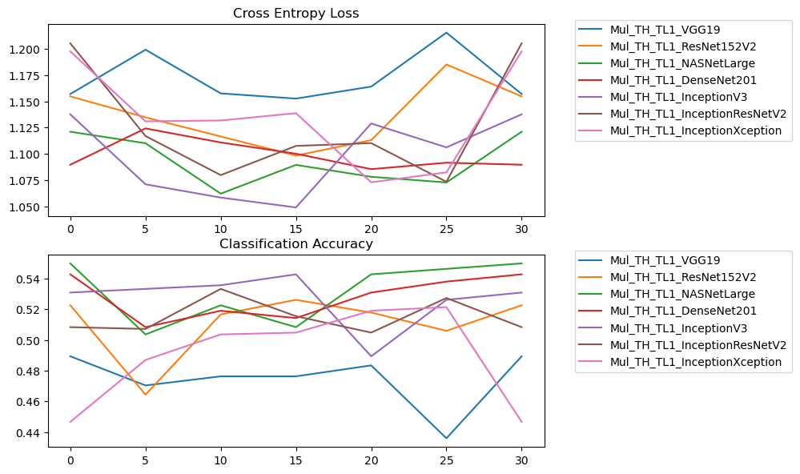

```python
from crack_utils import compare_all_result_multi

compare_all_result_multi(histories, filename="model_plot/Compare_{}_{}_{}.png".format(CLASS, PRE, TECH), end=30, step=5)
```

Save epochs history:

```python
from crack_utils import save_history

save_history(histories, folder="epochs_history")
```